# Tecniche di machine learning per la classificazione dei tumori al seno

## 1. Introduzione

In questo foglio applicheremo alcune delle tecniche sviluppate nell'ambito del machine learning con l'obiettivo di classificare i tumori al seno dividendoli tra benigni o maligni, in base ad una serie di misure dirette effettuate sui tumori di una serie di pazienti in Wisconsin, stato federato degli USA. In particolare, applicheremo una tecnica volta alla riduzione della dimensionalità del nostro dataset, la PCA, e una tecnica di classificazione, l'SVM, che si pone l'obiettivo di trovare il migliore separatore tra le due classi, che in questo caso sono 'Benigno' e 'Maligno' (B e M).

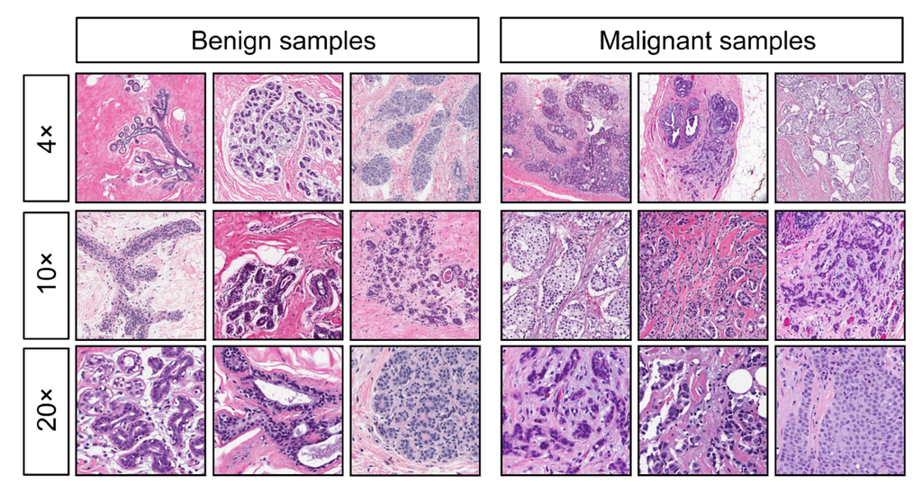

Importiamo le librerie che ci saranno utili per l'esplorazione del dataset:

```python
%matplotlib inline
# import mglearn
import warnings

import matplotlib.pyplot as plt
import numpy as np
import pandas as pd
import seaborn as sb

warnings.filterwarnings("ignore")
```

## 2. Descrizione del dataset

Il dataset che useremo è stato creato dal Dr. William H. Wolberg, fisico al University Of Winsconsin Hospital a Madison, Wisconsin, USA. Per creare questo dataset, Wolberg ha usato dei campioni prelevati da pazienti che presentavano masse tumorali solide al seno grazie anche al programma di calcolo grafico chiamato 'Xcyt' (usa algoritmi di adattamento particolari per individuare 10 features per ogni cellula in esame). Il dataset è composto da 569 righe e 31 colonne (30 features e una colonna rappresentante la classe d'appartenenza del tumore). Le features presenti sono:

- Radius (media delle distanze dal centro ai punti del perimetro)
- Texture (deviazione standard della scala dei valori di grigio)
- Perimeter
- Area
- Smoothness (variazioni locali della misura del raggio)
- Compactness
- Concavity (accentuatezza delle porzioni concave sulla superficie)
- Concave Points (quantità delle porzioni concave)
- Symmetry
- Fractal Dimension Queste features sono calcolate dal programma usando la media, il valore estremo e l'errore standard su ogni cellula. Ogni riga rappresenta il tumore al seno di un paziente differente.

## 3. Preparazione ed esplorazione del dataset

Prima di inziare a lavorare sul nostro dataset sono state effettuate delle operazioni preliminari volte a migliorare la comprensione di esso. Abbiamo eliminato la features 'Unnamed :32' in quanto composta da soli NaN. Stampiamo, inoltre, le prime 5 righe del dataset:

```python
df = pd.read_csv("data.csv")
df.head()
```

|  | id | diagnosis | radius_mean | texture_mean | perimeter_mean | area_mean | smoothness_mean | compactness_mean | concavity_mean | concave points_mean | ... | texture_worst | perimeter_worst | area_worst | smoothness_worst | compactness_worst | concavity_worst | concave points_worst | symmetry_worst | fractal_dimension_worst | Unnamed: 32 |
| --- | --- | --- | --- | --- | --- | --- | --- | --- | --- | --- | --- | --- | --- | --- | --- | --- | --- | --- | --- | --- | --- |
| 0 | 842302 | M | 17.99 | 10.38 | 122.80 | 1001.0 | 0.11840 | 0.27760 | 0.3001 | 0.14710 | ... | 17.33 | 184.60 | 2019.0 | 0.1622 | 0.6656 | 0.7119 | 0.2654 | 0.4601 | 0.11890 | NaN |
| 1 | 842517 | M | 20.57 | 17.77 | 132.90 | 1326.0 | 0.08474 | 0.07864 | 0.0869 | 0.07017 | ... | 23.41 | 158.80 | 1956.0 | 0.1238 | 0.1866 | 0.2416 | 0.1860 | 0.2750 | 0.08902 | NaN |
| 2 | 84300903 | M | 19.69 | 21.25 | 130.00 | 1203.0 | 0.10960 | 0.15990 | 0.1974 | 0.12790 | ... | 25.53 | 152.50 | 1709.0 | 0.1444 | 0.4245 | 0.4504 | 0.2430 | 0.3613 | 0.08758 | NaN |
| 3 | 84348301 | M | 11.42 | 20.38 | 77.58 | 386.1 | 0.14250 | 0.28390 | 0.2414 | 0.10520 | ... | 26.50 | 98.87 | 567.7 | 0.2098 | 0.8663 | 0.6869 | 0.2575 | 0.6638 | 0.17300 | NaN |
| 4 | 84358402 | M | 20.29 | 14.34 | 135.10 | 1297.0 | 0.10030 | 0.13280 | 0.1980 | 0.10430 | ... | 16.67 | 152.20 | 1575.0 | 0.1374 | 0.2050 | 0.4000 | 0.1625 | 0.2364 | 0.07678 | NaN |

5 rows × 33 columns

```python
x = df.drop(columns=["id", "diagnosis", "Unnamed: 32"])
y = df["diagnosis"]
x
```

|  | radius_mean | texture_mean | perimeter_mean | area_mean | smoothness_mean | compactness_mean | concavity_mean | concave points_mean | symmetry_mean | fractal_dimension_mean | ... | radius_worst | texture_worst | perimeter_worst | area_worst | smoothness_worst | compactness_worst | concavity_worst | concave points_worst | symmetry_worst | fractal_dimension_worst |
| --- | --- | --- | --- | --- | --- | --- | --- | --- | --- | --- | --- | --- | --- | --- | --- | --- | --- | --- | --- | --- | --- |
| 0 | 17.99 | 10.38 | 122.80 | 1001.0 | 0.11840 | 0.27760 | 0.30010 | 0.14710 | 0.2419 | 0.07871 | ... | 25.380 | 17.33 | 184.60 | 2019.0 | 0.16220 | 0.66560 | 0.7119 | 0.2654 | 0.4601 | 0.11890 |
| 1 | 20.57 | 17.77 | 132.90 | 1326.0 | 0.08474 | 0.07864 | 0.08690 | 0.07017 | 0.1812 | 0.05667 | ... | 24.990 | 23.41 | 158.80 | 1956.0 | 0.12380 | 0.18660 | 0.2416 | 0.1860 | 0.2750 | 0.08902 |
| 2 | 19.69 | 21.25 | 130.00 | 1203.0 | 0.10960 | 0.15990 | 0.19740 | 0.12790 | 0.2069 | 0.05999 | ... | 23.570 | 25.53 | 152.50 | 1709.0 | 0.14440 | 0.42450 | 0.4504 | 0.2430 | 0.3613 | 0.08758 |
| 3 | 11.42 | 20.38 | 77.58 | 386.1 | 0.14250 | 0.28390 | 0.24140 | 0.10520 | 0.2597 | 0.09744 | ... | 14.910 | 26.50 | 98.87 | 567.7 | 0.20980 | 0.86630 | 0.6869 | 0.2575 | 0.6638 | 0.17300 |
| 4 | 20.29 | 14.34 | 135.10 | 1297.0 | 0.10030 | 0.13280 | 0.19800 | 0.10430 | 0.1809 | 0.05883 | ... | 22.540 | 16.67 | 152.20 | 1575.0 | 0.13740 | 0.20500 | 0.4000 | 0.1625 | 0.2364 | 0.07678 |
| ... | ... | ... | ... | ... | ... | ... | ... | ... | ... | ... | ... | ... | ... | ... | ... | ... | ... | ... | ... | ... | ... |
| 564 | 21.56 | 22.39 | 142.00 | 1479.0 | 0.11100 | 0.11590 | 0.24390 | 0.13890 | 0.1726 | 0.05623 | ... | 25.450 | 26.40 | 166.10 | 2027.0 | 0.14100 | 0.21130 | 0.4107 | 0.2216 | 0.2060 | 0.07115 |
| 565 | 20.13 | 28.25 | 131.20 | 1261.0 | 0.09780 | 0.10340 | 0.14400 | 0.09791 | 0.1752 | 0.05533 | ... | 23.690 | 38.25 | 155.00 | 1731.0 | 0.11660 | 0.19220 | 0.3215 | 0.1628 | 0.2572 | 0.06637 |
| 566 | 16.60 | 28.08 | 108.30 | 858.1 | 0.08455 | 0.10230 | 0.09251 | 0.05302 | 0.1590 | 0.05648 | ... | 18.980 | 34.12 | 126.70 | 1124.0 | 0.11390 | 0.30940 | 0.3403 | 0.1418 | 0.2218 | 0.07820 |
| 567 | 20.60 | 29.33 | 140.10 | 1265.0 | 0.11780 | 0.27700 | 0.35140 | 0.15200 | 0.2397 | 0.07016 | ... | 25.740 | 39.42 | 184.60 | 1821.0 | 0.16500 | 0.86810 | 0.9387 | 0.2650 | 0.4087 | 0.12400 |
| 568 | 7.76 | 24.54 | 47.92 | 181.0 | 0.05263 | 0.04362 | 0.00000 | 0.00000 | 0.1587 | 0.05884 | ... | 9.456 | 30.37 | 59.16 | 268.6 | 0.08996 | 0.06444 | 0.0000 | 0.0000 | 0.2871 | 0.07039 |

569 rows × 30 columns

```python
df.info()
```

```
<class 'pandas.core.frame.DataFrame'>
RangeIndex: 569 entries, 0 to 568
Data columns (total 33 columns):
 #   Column                   Non-Null Count  Dtype
---  ------                   --------------  -----
 0   id                       569 non-null    int64
 1   diagnosis                569 non-null    object
 2   radius_mean              569 non-null    float64
 3   texture_mean             569 non-null    float64
 4   perimeter_mean           569 non-null    float64
 5   area_mean                569 non-null    float64
 6   smoothness_mean          569 non-null    float64
 7   compactness_mean         569 non-null    float64
 8   concavity_mean           569 non-null    float64
 9   concave points_mean      569 non-null    float64
```

[output cut: 25 more lines]

```python
df.describe()
```

|  | id | radius_mean | texture_mean | perimeter_mean | area_mean | smoothness_mean | compactness_mean | concavity_mean | concave points_mean | symmetry_mean | ... | texture_worst | perimeter_worst | area_worst | smoothness_worst | compactness_worst | concavity_worst | concave points_worst | symmetry_worst | fractal_dimension_worst | Unnamed: 32 |
| --- | --- | --- | --- | --- | --- | --- | --- | --- | --- | --- | --- | --- | --- | --- | --- | --- | --- | --- | --- | --- | --- |
| count | 5.690000e+02 | 569.000000 | 569.000000 | 569.000000 | 569.000000 | 569.000000 | 569.000000 | 569.000000 | 569.000000 | 569.000000 | ... | 569.000000 | 569.000000 | 569.000000 | 569.000000 | 569.000000 | 569.000000 | 569.000000 | 569.000000 | 569.000000 | 0.0 |
| mean | 3.037183e+07 | 14.127292 | 19.289649 | 91.969033 | 654.889104 | 0.096360 | 0.104341 | 0.088799 | 0.048919 | 0.181162 | ... | 25.677223 | 107.261213 | 880.583128 | 0.132369 | 0.254265 | 0.272188 | 0.114606 | 0.290076 | 0.083946 | NaN |
| std | 1.250206e+08 | 3.524049 | 4.301036 | 24.298981 | 351.914129 | 0.014064 | 0.052813 | 0.079720 | 0.038803 | 0.027414 | ... | 6.146258 | 33.602542 | 569.356993 | 0.022832 | 0.157336 | 0.208624 | 0.065732 | 0.061867 | 0.018061 | NaN |
| min | 8.670000e+03 | 6.981000 | 9.710000 | 43.790000 | 143.500000 | 0.052630 | 0.019380 | 0.000000 | 0.000000 | 0.106000 | ... | 12.020000 | 50.410000 | 185.200000 | 0.071170 | 0.027290 | 0.000000 | 0.000000 | 0.156500 | 0.055040 | NaN |
| 25% | 8.692180e+05 | 11.700000 | 16.170000 | 75.170000 | 420.300000 | 0.086370 | 0.064920 | 0.029560 | 0.020310 | 0.161900 | ... | 21.080000 | 84.110000 | 515.300000 | 0.116600 | 0.147200 | 0.114500 | 0.064930 | 0.250400 | 0.071460 | NaN |
| 50% | 9.060240e+05 | 13.370000 | 18.840000 | 86.240000 | 551.100000 | 0.095870 | 0.092630 | 0.061540 | 0.033500 | 0.179200 | ... | 25.410000 | 97.660000 | 686.500000 | 0.131300 | 0.211900 | 0.226700 | 0.099930 | 0.282200 | 0.080040 | NaN |
| 75% | 8.813129e+06 | 15.780000 | 21.800000 | 104.100000 | 782.700000 | 0.105300 | 0.130400 | 0.130700 | 0.074000 | 0.195700 | ... | 29.720000 | 125.400000 | 1084.000000 | 0.146000 | 0.339100 | 0.382900 | 0.161400 | 0.317900 | 0.092080 | NaN |
| max | 9.113205e+08 | 28.110000 | 39.280000 | 188.500000 | 2501.000000 | 0.163400 | 0.345400 | 0.426800 | 0.201200 | 0.304000 | ... | 49.540000 | 251.200000 | 4254.000000 | 0.222600 | 1.058000 | 1.252000 | 0.291000 | 0.663800 | 0.207500 | NaN |

8 rows × 32 columns

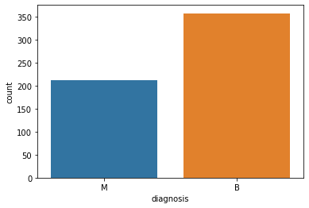

```python
sb.countplot(df["diagnosis"], label="Count")
```

[output not shown]

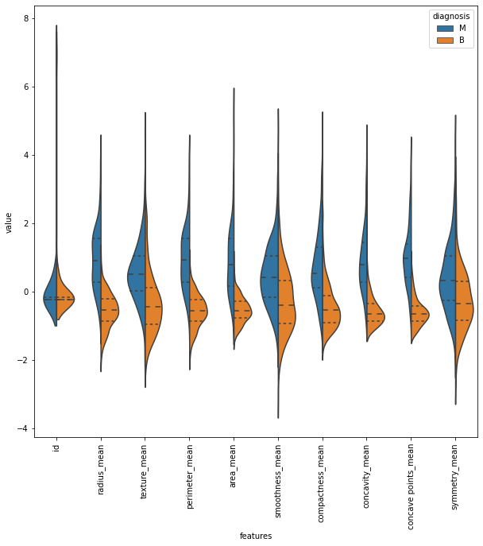

```python
data_dia = df.diagnosis
list = ["diagnosis"]
data = df.drop(list, axis=1)
data_n_2 = (data - data.mean()) / (data.std())  # standardization
data = pd.concat([df.diagnosis, data_n_2.iloc[:, 0:10]], axis=1)
data = pd.melt(data, id_vars="diagnosis", var_name="features", value_name="value")
plt.figure(figsize=(10, 10))
sb.violinplot(
    x="features", y="value", hue="diagnosis", data=data, split=True, inner="quart"
)
plt.xticks(rotation=90)
```

Utilizziamo una heatmap per cercare le correlazioni tra le features e ,nel caso, eliminiamo quelle altamente correlate fra loro. Questa operazione è utile per diminuire la dimensionalità del nostro problema. Nel nostro caso applicheremo direttamente la PCA, in quanto ha proprio lo scopo di ridurre le features correlate fra loro.

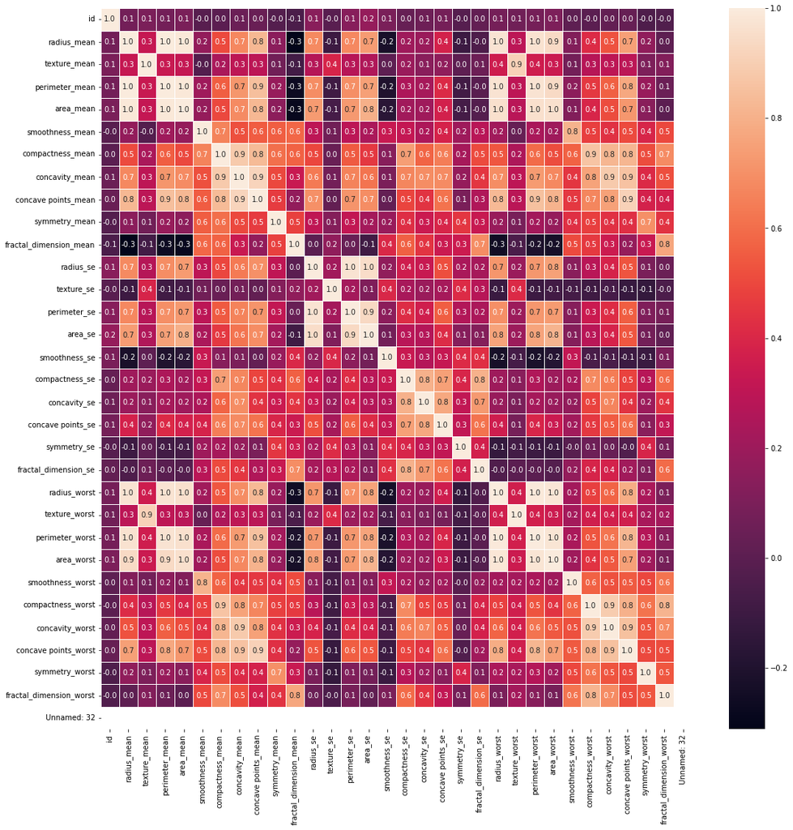

```python
# correlation map
f, ax = plt.subplots(figsize=(18, 18))
sb.heatmap(df.corr(), annot=True, linewidths=0.5, fmt=".1f", ax=ax)
```

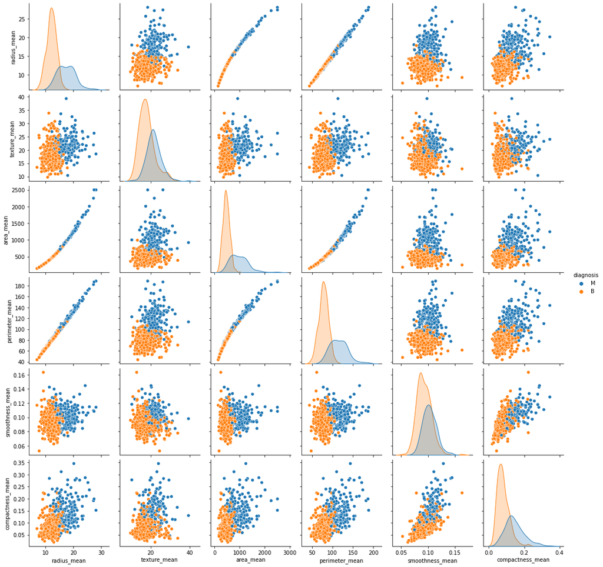

```python
sb.pairplot(
    df,
    hue="diagnosis",
    vars=[
        "radius_mean",
        "texture_mean",
        "area_mean",
        "perimeter_mean",
        "smoothness_mean",
        "compactness_mean",
    ],
)
```

## Analisi Componenti Principali (PCA)

Finita la prima fase di preparazione ed esplorazione dei nostri dati, applicheremo la *Principal Componente Analysis (PCA)*, un noto algoritmo nell'ambito del machine learning volto alla 'dimensionality reduction'.

## Analisi componenti principali del dataset

Risulta utile rappresentare graficamente la quantità di varianza spiegata per numero di componenti principali prese in considerazione, che comunque sono disposte in ordine decrescente. Una operazione preliminare importante da effettuare è la *standardizzazione del dataset* che verrà implementata grazie alla classe *StandardScaler*. Questa operazione risulta necessaria quando alcuni attributi assumono valori in range numerici molto più elevati rispetto alla stragrande maggioranza degli attributi e questo può portare alla sovra-rappresentazione (in termini di varianza spiegata) della prima componente principale rispetto alle altre. Applicando lo *StandardScaler* otteniamo ,solitamente, un grafico più regolare.

Associamo valori '0' e '1' alle nostre due classi, attraverso il 'label encoding'. Questa operazione non viene eseguita anche sulle features in quanto potrebbero insediarsi delle relazioni d'ordine che andrebbero a confondere gli algoritmi di apprendimento. Dividiamo il dataset in training e test set, con lo scopo di addestrare al meglio il modello su una porzione limitata di dati, per poi *testare* la sua efficacia su dati *nuovi* (test set), sui quali il modello non è stato influenzato.

```python
from sklearn.metrics import accuracy_score, confusion_matrix, f1_score
from sklearn.model_selection import train_test_split
from sklearn.preprocessing import LabelEncoder, StandardScaler

le = LabelEncoder()
```

```python
df["diagnosis"] = le.fit_transform(df["diagnosis"])
df["diagnosis"]
```

```
0      1
1      1
2      1
3      1
4      1
      ..
564    1
565    1
566    1
567    1
568    0
Name: diagnosis, Length: 569, dtype: int64
```

```python
y = df["diagnosis"]
y
```

```
0      1
1      1
2      1
3      1
4      1
      ..
564    1
565    1
566    1
567    1
568    0
Name: diagnosis, Length: 569, dtype: int64
```

```python
X_train, X_test, y_train, y_test = train_test_split(x, y, test_size=0.30, random_state=42)
y_train.shape
```

```
(398,)
```

```python
from sklearn.decomposition import PCA
```

```python
pca2 = PCA()
pca2.fit(X_train)
x2_pca = pca2.transform(X_train)
x2_pca_test = pca2.transform(X_test)
x2_pca_test.shape
```

```
(171, 30)
```

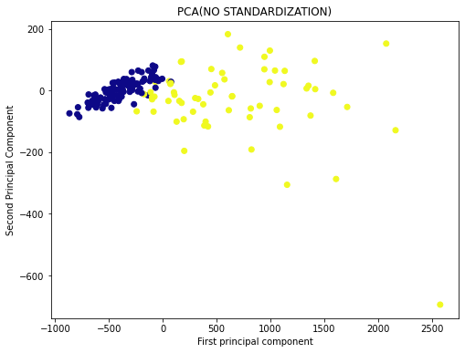

```python
plt.figure(figsize=(8, 6))
plt.scatter(x2_pca_test[:, 0], x2_pca_test[:, 1], c=y_test, cmap="plasma")
plt.xlabel("First principal component")
plt.ylabel("Second Principal Component")
plt.title("PCA(NO STANDARDIZATION)")
```

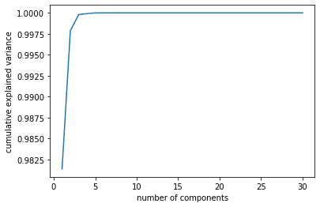

```python
z = np.arange(1, 31, 1)
plt.plot(z, np.cumsum(pca2.explained_variance_ratio_))
plt.xlabel("number of components")
plt.ylabel("cumulative explained variance");
```

```python
scaler = StandardScaler()
scaler.fit(X_train)
scaled_data = scaler.transform(X_train)
scaled_data_test = scaler.transform(X_test)
```

```python
pca1 = PCA(0.90)
pca1.fit(scaled_data)
x1_pca = pca1.transform(scaled_data)
x1_pca_test = pca1.transform(scaled_data_test)
x1_pca_test.shape
```

```
(171, 7)
```

```python
x1_pca.shape
```

```
(398, 7)
```

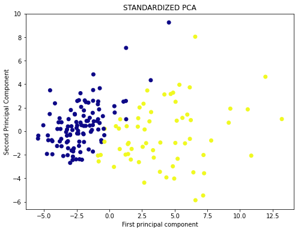

```python
plt.figure(figsize=(8, 6))
plt.scatter(x1_pca_test[:, 0], x1_pca_test[:, 1], c=y_test, cmap="plasma")
plt.xlabel("First principal component")
plt.ylabel("Second Principal Component")
plt.title("STANDARDIZED PCA")
```

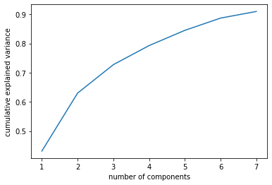

```python
z1 = np.arange(1, 8, 1)
plt.plot(z1, np.cumsum(pca1.explained_variance_ratio_))
plt.xlabel("number of components")
plt.ylabel("cumulative explained variance");
```

```python
pca = PCA(n_components=2)
pca.fit(scaled_data)
x_pca = pca.transform(scaled_data)
x_pca_test = pca.transform(scaled_data_test)
x_pca_test.shape
```

```
(171, 2)
```

```python
reformed = pd.DataFrame(x_pca_test)
reformed.columns = ["PCA-1", "PCA-2"]
reformed.head()
```

|  | PCA-1 | PCA-2 |
| --- | --- | --- |
| 0 | -0.750231 | 0.700519 |
| 1 | 2.668833 | -4.373020 |
| 2 | 1.473907 | -0.992619 |
| 3 | -0.857202 | 2.532869 |
| 4 | -1.610946 | 2.433481 |
| ... | ... | ... |
| 166 | -3.261528 | -0.943891 |
| 167 | -1.262180 | -1.729447 |
| 168 | 1.277060 | 7.088883 |
| 169 | 2.900284 | 3.467480 |
| 170 | 1.081161 | 2.519945 |

171 rows × 2 columns

```python
df1 = pd.DataFrame(y_test)
df1.reset_index(drop=True)
```

|  | diagnosis |
| --- | --- |
| 0 | 0 |
| 1 | 1 |
| 2 | 1 |
| 3 | 0 |
| 4 | 0 |
| ... | ... |
| 166 | 0 |
| 167 | 0 |
| 168 | 0 |
| 169 | 1 |
| 170 | 0 |

171 rows × 1 columns

```python
##final_df = pd.concat([reformed,df1], axis=1)
#final_df.columns = ["PCA-1", "PCA-2", "Target"]
#final_df
```

[output not shown]

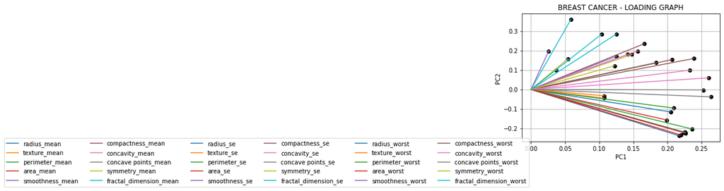

```python
plt.figure()
for i in range(pca.n_features_):
    plt.plot([0, pca.components_[0, i]], [0, pca.components_[1, i]], label=x.columns[i])
plt.scatter(pca.components_[0, :], pca.components_[1, :], c="k")
plt.legend(loc="upper right", bbox_to_anchor=(0.05, 0.05), ncol=6)
plt.title("BREAST CANCER - LOADING GRAPH")
plt.xlabel("PC1")
plt.ylabel("PC2")
plt.grid()
plt.show()
```

## Support Vector Machine (SVM)

Nel machine learning, la tecnica SVM è un modello di apprendimento supervisionato che analizza il dataset con due scopi principali: la *classificazione* e la *analisi di regressione*. Noi ci occuperemo della classificazione che consiste nel predire a quale classe appartengono i dati in input attraverso un modello sviluppato in una fase iniziale, detta di *training*. La SVM si propone esattamente questo obiettivo. Inizieremo, come per la PCA, spiegando i principi matematici che stanno alla base di questo modello.

#### Primal SVM

Per semplicità ci poniamo nel caso a due sole classi. Indichiamo con $x_i$ l'i-esimo punto del dataset e con $y_i=\pm1$ la classe a cui appartiene ($i=1,...,N$), consideriamo cioè il *training set*: $$\left\{\left(x_1,y_1\right),...,\left(x_N,y_N\right)\right\}\subset\mathbb{R}^n\times\left\{\pm1\right\}$$ L'idea è quella di costruire il "migliore" iperpiano che separi, basandosi solo sul *training set*, i punti delle due classi, classificandoli poi come nuovi punti grazie alla loro nuova posizione relativa a questo iperpiano. Questo non funzione sempre in quanto è possibile che le classi non siano perfettamente separabili da un iperpiano, vedremo che sarà comunque possibile classificare attraverso metodi più elaborati. Supponiamo, quindi, che esista un iperpiano identificato dalla coppia $(w,b)$ dove $w$ è un vettore ortogonale all'iperpiano e $b$ è uno scalare, tale per cui vale: $$y_i (\left \langle w,xi \right \rangle+b) ≥ 1 \qquad ∀i=1,…,N$$ E in questo caso diciamo che le classi sono *linearmente separabili*. Con queste ipotesi, esistono infiniti iperpiani separatori: il migliore fra tutti, sarà quello che massimizza il *margine*, cioè la distanza tra l'iperpiano e il punto del dataset più vicino a esso. Indichiamo con $r$ il margine e possiamo scrivere una prima formulazione del metodo: $$max_{w,b,r}r$$ soggetto ai vincoli: $$y_i(\left \langle {w,xi} \right \rangle+b)≥r \qquad ∀i=1,…,N$$ $$\left\|w_1\right\|=1$$ $$r>0$$ Si può dimostrare che ciò è equivalente a mostrare che: $$min_{w,b} \frac{1}{2}{\left\|w\right\|}^{2}$$ soggetto a: $$y_i(\left \langle {w,xi} \right \rangle+b)≥1 \qquad ∀i=1,…,N$$ che è nota come *formulazione primale*. Per poter passare da una formulazione all'altra abbiamo fissato a 1 la distanza minima fra iperpiano e i punti del dataset, ottenendo che $r=\frac{1}{\left\|w\right\|}$. Al posto di imporre che $w$ sia un versore, facciamo variare la "scala" rispetto la quale misuriamo le distanze dei dati dall'iperpiano.

#### Dual SVM

Spesso si risolve il problema di ottimizzazione visto in precedenza passando per il problema duale, introducendo una variabile $\alpha_i≥0$ per ogni vincolo, e calcolando la lagrangiana del problema. Il modello Dual SVM è dato da: $$\min_{\alpha} {\frac{1}{2}}\sum_{i=1}^{N}\sum_{j=1}^{N} y_iy_jα_iα_j\left \langle x_i,x_j \right \rangle-\sum_{i=1}^{N} α_i$$ soggetto a: $$\sum_{i=1}^{N}\alpha_iy_i=0,\ \ \alpha_i\geq0\ \ \forall i=1,\ldots,N$$ Chiamiamo $\alpha^*$ la soluzione del problema duale. Gli unici $\alpha_{i}^{*}$ non nulli sono quelli associati ai punti $x_i$ che stanno sul margine. Chiamiamo questo tipo di punti *support vectors*. Quindi, gli unici punti importanti per l'algoritmo sono quelli più vicini all'iperpiano separatore (quasi intuitivo a livello geometrico). Indichiamo con $I_{sv}$ l'insieme degli indici associati ai *support vectors* e ricaviamo le espressioni di $w^+$ e di $b^*$ (le soluzioni del problema primale) in funzione di $\alpha^{*}$ come: $$w^*=\sum_{i\in I_{sv}}{y_i\alpha_i^\ast x_i}$$ $$b^{*}=\frac{1}{\left|I_{sv}\right|}\sum_{i∈I_{sv}} (y_i - \left \langle w*,xi \right \rangle)$$ Abbiamo che la nostra *decision function* sarà: $$h(x)=sign(\left \langle w^{*},x_i \right \rangle+b^{*})$$

#### Soft Margin SVM

Entriamo ora nel caso di punti non linearmente separibli. Il *soft margin SVM* cerca di rispondere a problemi di questo tipo attraverso un rilassamento del modello precedente effettuato ammettendo un numero controllato di errori di classificazione. Per valutare questo tipo di errori, introduciamo delle variabili di *slack* $\xi_{i}≥0$ associate ai punti $x_i$: la quantità di queste variabili deve essere tale che, se la q.tà viene sommata a $y_i(\left \langle {w,xi} \right \rangle+b$, questo numero è maggiore di 1. Sommiamo le *slack* alla funzione obiettivo in modo da controllare il numero di questi errori. Definiamo il modello tramite il seguente problema di minimizzazione: $$min_{w,b,\xi} \frac{1}{2} {\left\|w\right\|}^{2}+C\sum_{i=1}^{N} \xi_i$$ soggetta al vincolo: $$y_i(\left \langle {w,xi} \right \rangle+b)≥1-\xi_{i}$$ Il parametro C è un grado di libertà del problema che rappresenta il costo che si paga per una violazione del margine: quando C è piccolo avremo un margine ampio, mentre, quando C tende a infinito si ricade nella formulazione *Hard Margin SVM* appena vista sopra in cui non ci sono errori ammissibili.

#### Kernel SVM

Quando la distribuzione dei dati nello spazio è fortemente non lineare, le varianti del *linear SVM* falliscono. Occorre perciò ricorrere ad una versione alternativa e più complessa di questo metodo, detto *kernel SVM*. In questo modo, riusciremo ad ottenere una *decision boundary* anche non necessariamente lineare.

##### Prima formulazione:

L'idea alla base di questo modello è quella di mappare i punti in uno spazio di Hilbert di dimensione sufficientemente grande da consentire la separazione per mezzo di un nuovo iperpiano. Si considera un *training set*: $$\left\{\left(x_1,y_1\right),...,\left(x_N,y_N\right)\right\}\subset\mathbb{R}^n\times\left\{\pm1\right\}$$ con $x_n$ le *features* e $y_n$ le *labels*. Sia inoltre: $$\phi: \mathbb{R}^n\rightarrow\mathbb{R}^m,\quad con \quad m>>n,$$ la *feature map* che manda il dataset originale in uno spazio m-dimensionale (molto più grande di n). Applichiamo, quindi, la *linear SVM* al dataset trasformato tramite $\phi$: $$\left\{\left(\phi(x_1),y_1\right),...,\left(\phi(x_N),y_N\right)\right\}\in\mathbb{R}^m\times\left\{\pm1\right\}$$ ottenendo il seguente problema: $$\min_{\alpha} {\frac{1}{2}}\sum_{i=1}^{N}\sum_{j=1}^{N} y_iy_jα_iα_j\left \langle \phi(x_i),\phi(x_j) \right \rangle-\sum_{i=1}^{N} α_i$$ soggetto a: $$\sum_{i=1}^{N}\alpha_iy_i=0,\ \ \alpha_i\geq0\ \ \forall i=1,\ldots,N$$

Chiamiamo $\alpha^*$ la soluzione del problema precedente, abbiamo che la *decision function* ha la seguente forma:

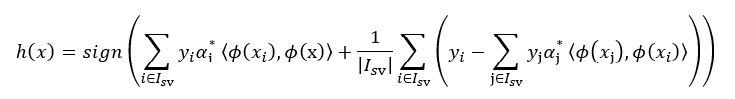

Questa formula porta con sè un numero molto elevato di prodotti scalari in $\mathbb{R}^m$ che grava pesantemente sul costo computazionale dell'algoritmo. Per ovviare a questo problema, si introduce il *kernel*.

#### Il kernel trick

Possiamo notare dalla forma della *decision function* come la $\phi$ appaia soltanto nel prodotto scalare. Per questo motivo, si può ridurre il costo computazionale cercando di evitare il calcolo esplicito dell'immagine tramite $\phi$ e del prodotto scalare in $\mathbb{R}^m$ grazie ad una mappa $k$ che chiamiamo *kernel*: $$k:\mathbb{R}^n\times\mathbb{R}^n\rightarrow\mathbb{R}$$ così definita: $$k(x_i,x_j)=\left \langle \phi(x_i),\phi(x_j) \right \rangle$$ Sostituendo questa espressione nella *decision function* sopra definita otteniamo un problema meno pesante dal punto di vista computazionale. Adottando la formulazione duale, il problema diventa parametrico su $\alpha\in\mathbb{R}^N$.

#### Reproducing Kernel Hilbert Spaces (RKHS)

Per fare in modo che $k$ sia un *kernel*, la *matrice di Gram* $G_{ij}=k(x_i,x_j)$ deve essere simmetrica e semidefinita positiva contemporaneamente. Questà proprietà può essere meglio compresa definendo i *Reproducing Kernel Hilber Spaces*, particolari spazi di Hilbert.

**DEF**: Sia $\chi\subset\mathbb{R}^{\chi}$ un insieme non vuoto, consideriamo lo spazio di Hilbert $(G,(\left \langle \cdot,\cdot \right \rangle)_{G})$ con $G\in\mathbb{R}^{\chi}$. $G$ è detto *Reproducing Kernel Hilbert Spaces (o RKHS)* con *kernel riproducente* $k:\mathbb{R}^n\times\mathbb{R}^n\rightarrow\mathbb{R}$ se:

1. $\forall x\in\chi, k_{x}=k(x,\cdot)\in G$ ;
2. $\forall x\in\chi, k(x,x)<\infty$;
3. $\forall x\in\chi, \forall g\in G, g(x)={\left \langle g,k_{x} \right \rangle}_G$ Dalla 1. e dalla 3. segue che: $$\forall x_i,x_j \in\chi, k(x_i,x_j)=k_{x_i}(x_j)=(\left \langle k_{x_i},k_{x_j} \right \rangle)_{G}$$ In questo caso, $k_{x_i}$ e $k_{x_j}$ prendono il ruolo di $\phi(x_i)$ e $\phi(x_j)$. E' possibile dimostrare che se $k$ soddisfa le proprietà viste sopra, allora la *matrice di Gram* $G$ è simmetrica e semidefinita positiva. Inoltre, vale il seguente teorema: **TEOREMA di Moore-Aronszajn**: Dato $\chi$ non vuoto e una funzione $k:\chi\times\chi\rightarrow\mathbb{R}$ simmetrica e semidefinita positiva, allora esiste ed è unico un $G\in\mathbb{R}^{\chi}$ *RKHS* con *kernel riproducente* $k$.(a meno di isomorfismi) In questo modo, ci siamo liberati della feature map e possiamo utilizzare il *kernel* $k$ dall'inizio come una generalizzazione del prodotto scalare.

Applichiamo ora il metodo SVM con le nostre 2 componenti principali. In particolare, usiamo prima la versione *linear* e poi la versione *kernelizzata*. Prima di procedere, dividiamo il nostro dataset in due parti: training e test set

#### Linear SVM con 2 componenti principali

```python
from sklearn.model_selection import train_test_split

#X = final_df[["PCA-1", "PCA-2"]]
#y = final_df["Target"]
#y
```

```python
X_train, X_test, y_train, y_test = train_test_split(
    reformed, df1, test_size=0.20, random_state=42
)
```

```python
from sklearn.svm import SVC

model = SVC(kernel="linear")
model.fit(X_train, y_train)
```

```
SVC(kernel='linear')
```

```python
predictions = model.predict(X_test)
from sklearn.metrics import classification_report, confusion_matrix

print(confusion_matrix(y_test, predictions))
```

```
[[27  0]
 [ 0  8]]
```

```
[Text(0.5, 15.0, 'Prediction'), Text(33.0, 0.5, 'Feedback')]
```

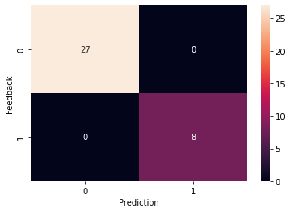

```python
confusion = confusion_matrix(y_test, predictions)
s = sb.heatmap(confusion, annot=True)
s.set(xlabel="Prediction", ylabel="Feedback")
```

```python
print(classification_report(y_test, predictions))
```

```
              precision    recall  f1-score   support

           0       1.00      1.00      1.00        27
           1       1.00      1.00      1.00         8

    accuracy                           1.00        35
   macro avg       1.00      1.00      1.00        35
weighted avg       1.00      1.00      1.00        35
```

```python
X1_train, X1_test, y1_train, y1_test = train_test_split(
    reformed, df1, test_size=0.20, random_state=42
)
```

```python
from sklearn.model_selection import cross_val_score

degree = [2, 3, 4, 5, 6]
acc_score = []
for d in degree:
    svc = SVC(kernel="poly", degree=d)
    scores = cross_val_score(svc, X1_train, y1_train, cv=10, scoring="accuracy")
    acc_score.append(scores.mean())
print(acc_score)
```

```
[0.6983516483516483, 0.8395604395604396, 0.728021978021978, 0.7950549450549451, 0.7346153846153846]
```

```python
svc = SVC(kernel="poly", degree=3)
svc.fit(X1_train, y1_train)
predictions = model.predict(X1_test)
from sklearn.metrics import classification_report, confusion_matrix

print(confusion_matrix(y1_test, predictions))
```

```
[[27  0]
 [ 0  8]]
```

```
[Text(0.5, 15.0, 'Prediction'), Text(33.0, 0.5, 'Feedback')]
```

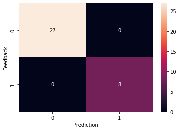

```python
confusion = confusion_matrix(y1_test, predictions)
s = sb.heatmap(confusion, annot=True)
s.set(xlabel="Prediction", ylabel="Feedback")
```

```python
print(classification_report(y1_test, predictions))
```

```
              precision    recall  f1-score   support

           0       1.00      1.00      1.00        27
           1       1.00      1.00      1.00         8

    accuracy                           1.00        35
   macro avg       1.00      1.00      1.00        35
weighted avg       1.00      1.00      1.00        35
```